[figure not shown]

CLASE 3

VISUALIZACIÓN DE DATOS

Gabriel Sotomayor

Marzo 2024

OBJETIVO DE LA CLASE

Introducir el uso de ggplot en R para ciencias sociales.

VISUALIZACIÓN DE DATOS

“La visualización es una actividad humana fundamental. Una buena

visualización te mostrará cosas que no esperabas o hará surgir nuevas preguntas

acerca de los datos. También puede darte pistas acerca de si estás haciendo las

preguntas equivocadas o si necesitas recolectar datos diferentes. Las

visualizaciones pueden sorprenderte, pero no escalan particularmente bien, ya

que requieren ser interpretadas por una persona.”(Wickham, 2017)

La visualización de datos resulta de gran utilidad en las distintas etapas del

análisis de datos, por su capacidad de transmitirnos de manera comprensible

grandes cantidades de información. Nos centraremos en su uso para análisis

exploratorio y para la comunicación de resultados.

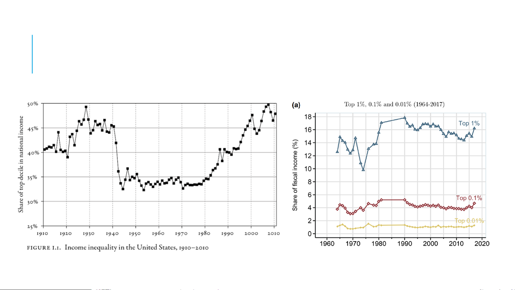

EJEMPLOS DE VISUALIZACIÓN EN CIENCIAS

SOCIALES

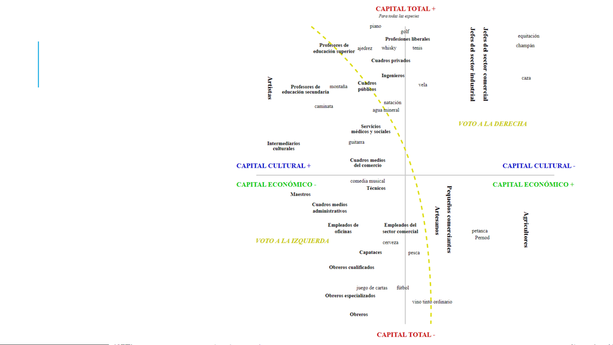

EJEMPLOS DE

VISUALIZACIÓN EN

CIENCIAS SOCIALES

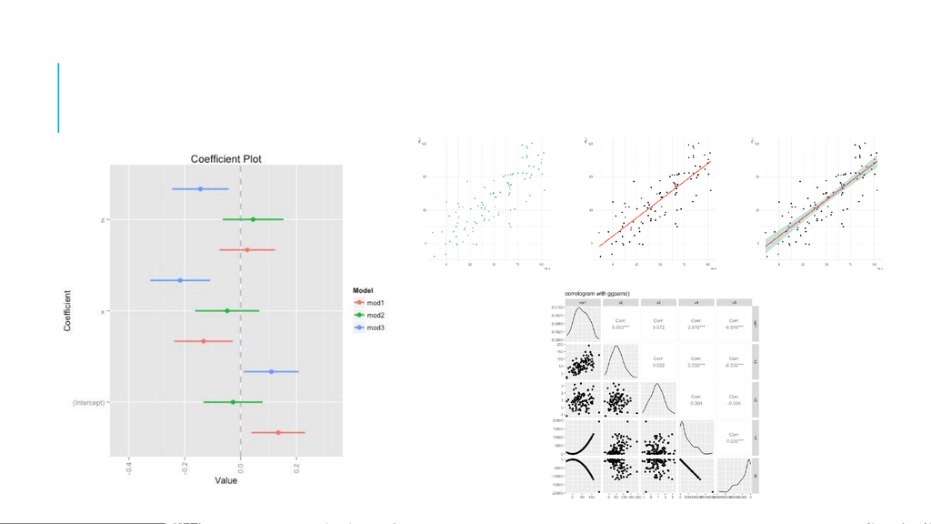

EJEMPLOS DE LAS TÉCNICAS DEL CURSO

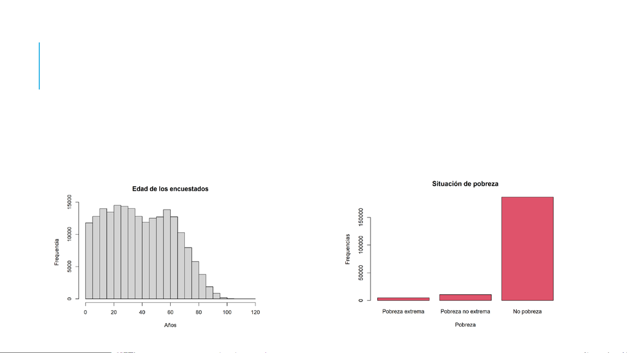

VISUALIZACIÓN EN R BASE

Rbase contiene algunas herramientas básicas de visualización de datos que nos

permitirán obtener rápidamente visualizaciones de los datos para la etapa

exploratoria de nuestros análisis.

[figure not shown]

CONSTRUCCIÓN DE GRÁFICOS CON GGPLOT2

La principal herramienta de visualización de datos en Res el paquete ggplot2, que

forma parte de tidyverse. ggplot2 implementa la gramática de los gráficos, un

sistema coherente para describir y construir gráficos.

Su versatilidad y capacidad de obtener resultados visualmente atractivos lo hacen

más pertinente para tareas de presentación de resultados, tanto apúblicos

especializados como no especializados.

Veremos los elementos básicos para poder hacer uso del paquete más adelante en

el contexto de las técnicas estadísticas a ver en el curso.

[figure not shown]

Elementos que componen un gráfico construido mediante la función

ggplot.

Capa

Descripción

Datos

Conjunto de información que se representará de manera gráfica. En nuestro caso se

trata de una o más variables, o una base de datos.

Estética

Escala en la cual se posicionará la información de interés. Refiere al

posicionamiento de la información a representar sobre los diferentes ejes y

dimensiones del gráfico resultante. Hablamos del posicionamiento de variables en

los ejes X e Y como también de la posibilidad de indicar variables que pueden ser

posicionadas como color de relleno dentro de los diferentes ejes, como una función

de transparencia, etc.

Geometría

Formas, elementos visuales, que se emplearán para representar visualmente la

información ya consignada en los

datos y ubicada en las diferentes posiciones del

gráfico mencionadas en la

estética. Cada especificación de geometría permite

visualizar diferentes características de la(s) variable(s) y su distribución.

Boccardo y Ruiz, RStudio para Estadística Descriptiva en Ciencias Sociales

GRAMÁTICA DE GRÁFICOS CON GGPLOT2